# Final Project

It makes sense the highest rated Star Wars has the word great in its most prevalent topic.

```r
# process text
process_text <- textProcessor(ep5$comment, meta = ep5)
```

```
## Building corpus...
## Converting to Lower Case...
## Removing punctuation...
## Removing stopwords...
## Removing numbers...
## Stemming...
## Creating Output...
```

```r
#prepare the different fields needed for topic modeling
prepped_text <- prepDocuments(process_text$documents, process_text$vocab, process_text$meta)
```

```
## Removing 1270 of 2442 terms (1270 of 9613 tokens) due to frequency
## Your corpus now has 135 documents, 1172 terms and 8343 tokens.
```

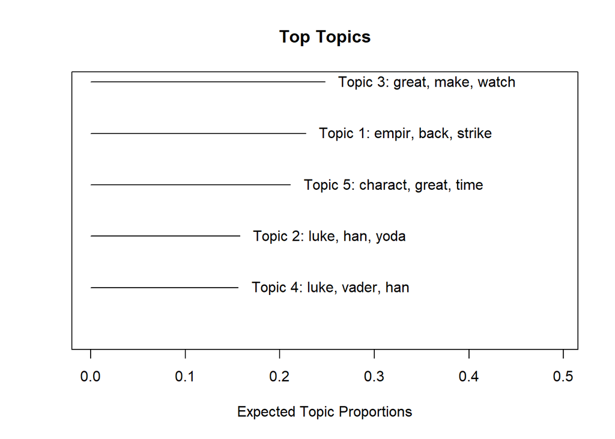

```r
# most common words of the Topics - 5 topics chosen
topics5 <- stm(documents = prepped_text$documents,
             vocab = prepped_text$vocab, seed = 1001,
             K = 5, verbose = FALSE)

plot(topics5)
```

```r
# most common words to come up
labelTopics(topics5)
```

```
## Topic 1 Top Words:
##       Highest Prob: empir, back, strike, charact, make, sequel, dark
##       FREX: strike, back, empir, villain, impact, instal, perfect
##       Lift: anticip, aspir, atmospher, chill, consider, delv, embodi
##       Score: atmospher, move, unforgett, rare, impact, titl, flaw
## Topic 2 Top Words:
##       Highest Prob: luke, han, yoda, william, vader, ford, darth
##       FREX: harrison, billi, dee, awesom, ford, fisher, revel
##       Lift: awesom, delight, irwin, oscar, overwhelm, tle, alec
##       Score: awesom, harrison, eventu, guin, alec, david, billi
## Topic 3 Top Words:
##       Highest Prob: great, make, watch, love, time, lot, end
##       FREX: opinion, lot, watch, amaz, interest, rememb, day
##       Lift: childhood, connect, henson, jim, situat, spell, tree
##       Score: winter, opinion, childhood, figur, tree, rememb, dad
## Topic 4 Top Words:
##       Highest Prob: luke, vader, han, empir, yoda, back, train
##       FREX: learn, train, begin, base, dagobah, duel, imperi
##       Lift: cruel, dispatch, lie, past, aid, bear, beast
##       Score: vadar, falcon, bear, millennium, tension, seek, flee
## Topic 5 Top Words:
##       Highest Prob: charact, great, time, action, make, stori, histori
##       FREX: climax, general, sci, rate, cast, incred, cultur
##       Lift: abil, actress, anim, balanc, bar, bitter, check
##       Score: general, prop, anim, issu, influenc, cracker, share
```

Topic Modeling Process for episode 9.

There is a lot of talk of character names. Trilogy is often mentioned most likely because it was the finale of the trilogy. Rating this movie in a way signifies the trilogy as a whole.

```r
# text processing for episode 9
process_text_9 <- textProcessor(ep9$comment, meta = ep9)
```

```
## Building corpus...
## Converting to Lower Case...
## Removing punctuation...
## Removing stopwords...
## Removing numbers...
## Stemming...
## Creating Output...
```

```r
prepped_text <- prepDocuments(process_text_9$documents, process_text_9$vocab, process_text_9$meta)
```

```
## Removing 1883 of 3803 terms (1883 of 17428 tokens) due to frequency
## Your corpus now has 225 documents, 1920 terms and 15545 tokens.
```

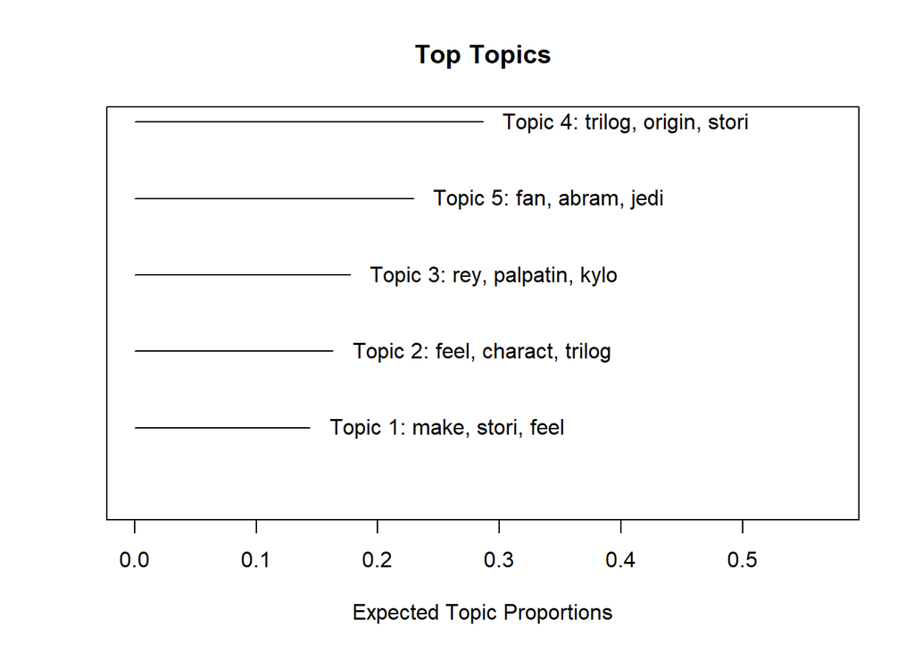

```r
# most common words of the Topics
topics5_ep9 <- stm(documents = prepped_text$documents,
             vocab = prepped_text$vocab, seed = 1001,
             K = 5, verbose = FALSE)

plot(topics5_ep9)
```

```r
# most popular words
labelTopics(topics5_ep9)
```

```
## Topic 1 Top Words:
##       Highest Prob: make, stori, feel, bad, charact, sens, scene
##       FREX: sidious, chase, viewer, expand, check, sequenc, relat
##       Lift: attent, bloat, case, charisma, compet, dialog, doom
##       Score: myth, viewer, reflect, dialog, quot, sidious, formula
## Topic 2 Top Words:
##       Highest Prob: feel, charact, trilog, make, great, episod, forc
##       FREX: ridley, daisi, boyega, isaac, oscar, driver, adam
##       Lift: acki, anthoni, argu, bang, beauti, billi, bit
##       Score: ridley, sign, daisi, billi, isaac, boyega, beauti
## Topic 3 Top Words:
##       Highest Prob: rey, palpatin, kylo, jedi, make, ren, forc
##       FREX: kill, kiss, heal, ghost, redempt, darth, snoke
##       Lift: acquir, belief, bliss, buri, celebr, chunk, convert
##       Score: kill, dude, eat, rey, kylo, dead, heal
## Topic 4 Top Words:
##       Highest Prob: trilog, origin, stori, disney, make, charact, bad
##       FREX: piec, histori, prequel, origin, review, money, hard
##       Lift: abysm, blame, crowd, earn, eras, frantic, initi
##       Score: vast, flaw, hollywood, rate, histori, theater, read
## Topic 5 Top Words:
##       Highest Prob: fan, abram, jedi, rise, bad, skywalk, stori
##       FREX: jar, johnson, fun, phantom, follow, enjoy, level
##       Lift: insist, acknowledg, boba, casual, cheapli, concern, extra
##       Score: jar, exsist, night, mere, satisfi, transform, music
```

Ultimately, the sentiment analysis rankings diverged from the numerical rankings, highlighting a disparity in how people convey emotions through words as opposed to numerical ratings. Focusing on Star Wars, the original trilogy emerged as the most popular, resonating both in numeric and sentiment rankings. Interestingly, both metrics converged in identifying Episode Five as the pinnacle Star Wars movie.

To enhance the study, future endeavors could involve gathering a more extensive dataset by aggregating comments from various websites. Additionally, employing multiple sentiment analysis tools could contribute to a more comprehensive and robust sentiment score, offering deeper insights into the emotional resonance within audience reviews.